# Initial Exploration Notebook

CS 333 Interactive Information Visualization

Author

Aaron, Rebecca, Connor, Janelys, Winnie

Published

May 26, 2026

## Dataset Description

For our final project, we are thinking of using the **Macro Indicators vs Asset Returns (1985–2024)** dataset. This dataset covers 40 years of macroeconomic and financial market data across 30 countries, including both developed and emerging markets. It links macro variables such as GDP growth, inflation, policy rates, unemployment, financial stress, and exchange rate changes to returns across five asset classes: equities, bonds, real estate, commodities, and cash.

The dataset is organized across several CSV files. The two main files for our analysis are `macro_indicators.csv`, which contains annual country-level macroeconomic data, and `asset_returns.csv`, which contains annual asset returns by country. These files can be joined by country, year, region, development level, and shock event. We also have supporting files such as `macro_monthly.csv`, which provides monthly G7 macro indicators, `correlations.csv`, which contains rolling macro-asset correlations, and `recession_episodes.csv`, which identifies recession periods across countries.

## Initial Data Exploration

```r
library(tidyverse)


# load all datasets
asset_returns <- read_csv("data/asset_returns.csv")
macro_indicators <- read_csv("data/macro_indicators.csv")
recession_episodes <- read_csv("data/recession_episodes.csv")
correlations <- read_csv("data/correlations.csv")
macro_monthly <- read_csv("data/macro_monthly.csv")

# quick look at the structure of the two main datasets
glimpse(asset_returns)
```

```
Rows: 1,200
Columns: 10
$ country     <chr> "USA", "USA", "USA", "USA", "USA", "USA", "USA", "USA", "U…
$ year        <dbl> 1985, 1986, 1987, 1988, 1989, 1990, 1991, 1992, 1993, 1994…
$ dev_level   <chr> "developed", "developed", "developed", "developed", "devel…
$ region      <chr> "NorthAmerica", "NorthAmerica", "NorthAmerica", "NorthAmer…
$ equities    <dbl> 18.93, 11.52, 0.58, 38.04, 8.31, 18.25, -17.66, 13.47, -4.…
$ bonds       <dbl> 7.05, 10.24, -4.12, 0.10, -2.60, 13.34, 8.85, 0.94, 9.53, …
$ real_estate <dbl> -7.43, 0.03, 3.02, 7.07, 29.12, 14.08, -8.96, 18.32, 0.51,…
$ commodities <dbl> 2.10, -27.53, 21.01, -15.35, -4.71, -15.15, -9.11, 14.75, …
$ cash        <dbl> 3.65, 3.78, 3.10, 3.32, 2.97, 2.77, 2.71, 2.78, 3.40, 3.48…
$ shock_event <chr> NA, NA, "Black Monday", NA, NA, "Gulf War / S&L crisis", "…
```

```r
glimpse(macro_indicators)
```

```
Rows: 1,200
Columns: 15
$ country         <chr> "USA", "USA", "USA", "USA", "USA", "USA", "USA", "USA"…
$ region          <chr> "NorthAmerica", "NorthAmerica", "NorthAmerica", "North…
$ dev_level       <chr> "developed", "developed", "developed", "developed", "d…
$ year            <dbl> 1985, 1986, 1987, 1988, 1989, 1990, 1991, 1992, 1993, …
$ gdp_growth      <dbl> 2.683, 2.627, 2.317, 2.105, 1.897, 1.293, 0.502, 0.837…
$ gdp_level       <dbl> 102.68, 105.38, 107.82, 110.09, 112.18, 113.63, 114.20…
$ inflation       <dbl> 1.668, 1.152, 0.794, 0.854, 0.532, 1.710, 2.132, 3.402…
$ policy_rate     <dbl> 4.127, 4.166, 4.095, 3.893, 3.668, 3.183, 3.189, 3.042…
$ unemployment    <dbl> 4.129, 4.075, 3.817, 4.130, 4.616, 4.469, 5.064, 5.066…
$ current_account <dbl> -6.902, -2.868, -3.370, -2.175, -3.228, -2.767, -5.914…
$ debt_to_gdp     <dbl> 59.33, 63.54, 64.35, 67.33, 67.82, 70.58, 72.51, 74.25…
$ fx_change       <dbl> 0.505, 1.339, 2.957, 4.777, -1.059, 1.980, -0.830, 0.0…
$ biz_confidence  <dbl> 54.42, 52.68, 52.57, 52.99, 55.75, 52.06, 48.09, 53.43…
$ fin_stress_idx  <dbl> 0.0, 0.0, 0.8, 0.0, 0.0, 0.6, 0.5, 0.0, 0.0, 0.0, 0.0,…
$ shock_event     <chr> NA, NA, "Black Monday", NA, NA, "Gulf War / S&L crisis…
```

```r
# what does a typical year look like for each investment type?
asset_returns |>
  summarize(
    `Avg Stock Return` = mean(equities),
    `Avg Bond Return` = mean(bonds),
    `Avg Real Estate Return` = mean(real_estate),
    `Avg Commodity Return` = mean(commodities),
    `Avg Cash Return` = mean(cash)
  )|>
  knitr::kable(digits = 2)
```

| Avg Stock Return | Avg Bond Return | Avg Real Estate Return | Avg Commodity Return | Avg Cash Return |
| --- | --- | --- | --- | --- |
| 3.62 | -1.18 | -0.15 | 6.76 | 6.32 |

```r
# how many countries and years are in the dataset?
asset_returns |> summarize(
  countries = n_distinct(country),
  years = n_distinct(year),
  total_rows = n()
)|>
  knitr::kable(digits = 2)
```

| countries | years | total_rows |
| --- | --- | --- |
| 30 | 40 | 1200 |

```r
# what crises are in the data and how many country-years were affected?
asset_returns |>
  filter(!is.na(shock_event)) |>
  group_by(shock_event) |>
  summarize(
    years = paste(unique(year), collapse = ", "),
    countries_affected = n_distinct(country),
    country_years = n(),
    .groups = "drop"
  ) |>
  arrange(years) |>
  knitr::kable()
```

| shock_event | years | countries_affected | country_years |
| --- | --- | --- | --- |
| Black Monday | 1987 | 30 | 30 |
| Gulf War / S&L crisis | 1990 | 30 | 30 |
| Recession | 1991 | 30 | 30 |
| Asian Financial Crisis | 1997 | 30 | 30 |
| LTCM / Russia default | 1998 | 30 | 30 |
| Dot-com bust / 9-11 | 2001 | 30 | 30 |
| Corporate scandals | 2002 | 30 | 30 |
| Global Financial Crisis | 2008 | 30 | 30 |
| GFC trough | 2009 | 30 | 30 |
| Euro debt crisis | 2011 | 30 | 30 |
| China slowdown | 2015 | 30 | 30 |
| COVID-19 | 2020 | 30 | 30 |
| COVID recovery / stimulus | 2021 | 30 | 30 |
| Inflation / rate hike cycle | 2022 | 30 | 30 |
| Rates plateau | 2023 | 30 | 30 |

## Data Structure

The asset_returns dataset contains 1,200 rows, one per country per year. The five return columns (equities, bonds, real_estate, commodities, cash) represent annual percentage returns for each investment type. The shock_event column identifies years with major economic crises such as the Global Financial Crisis or COVID-19.

The macro_indicators dataset contains the same 1,200 rows but captures economic conditions: inflation (annual price growth %), policy_rate (central bank interest rate %), gdp_growth (economic growth %), unemployment (jobless rate %), fx_change (currency movement vs USD %), and fin_stress_idx (financial stress score from 0-3).

## Story Introduction

Our three communication goals form a connected narrative about how macroeconomic conditions shape investment performance across countries and asset classes. We begin by exploring whether global macro shocks affect all investments equally, or whether different crises create different “winners” and “losers” across equities, bonds, commodities, real estate, and cash. We then investigate whether common macroeconomic signals, such as inflation and policy rates, carry the same meaning across developed and emerging markets, where economic volatility and instability can differ substantially. Finally, we explore whether inflation alone drives asset performance, or whether the response of central banks through monetary policy plays a more important role in determining how assets behave during inflationary periods.

## Communication Goals

### 1. How do macro shocks reshape cross-asset performance?

Different types of macro shocks, including growth slowdowns, inflation shocks, and periods of financial stress, may alter the relative performance of asset classes rather than affecting all assets uniformly. We want to explore whether returns across equities, bonds, real estate, commodities, and cash vary meaningfully between shock and non-shock periods, potentially creating different “winners” and “losers” depending on the macro environment. The goal is to show that asset performance depends not only on whether a crisis occurs, but also on the underlying nature of the macroeconomic shock.

The table shows that during shock years, equities drop from an average of +6.3% to -0.84%, while cash remains almost unchanged. The chart shows this pattern over time for the USA, with red shading marking crisis periods.

```r
shock_avg <- asset_returns |>
  mutate(shock = ifelse(is.na(shock_event), "No Shock", "Shock")) |>
  group_by(shock) |>
  summarize(
    Equities = mean(equities),
    Bonds = mean(bonds),
    `Real Estate` = mean(real_estate),
    Commodities = mean(commodities),
    Cash = mean(cash)
  )

shock_avg |>
  knitr::kable()
```

| shock | Equities | Bonds | Real Estate | Commodities | Cash |
| --- | --- | --- | --- | --- | --- |
| No Shock | 6.2919600 | -1.6084667 | 1.482040 | 7.016813 | 6.276187 |
| Shock | -0.8411556 | -0.4771778 | -2.877911 | 6.345111 | 6.400889 |

```r
# get the actual shock years for USA
usa_shocks <- asset_returns |>
  filter(country == "USA", !is.na(shock_event)) |>
  select(year, shock_event)

usa_shocks|>
  knitr::kable()
```

| year | shock_event |
| --- | --- |
| 1987 | Black Monday |
| 1990 | Gulf War / S&L crisis |
| 1991 | Recession |
| 1997 | Asian Financial Crisis |
| 1998 | LTCM / Russia default |
| 2001 | Dot-com bust / 9-11 |
| 2002 | Corporate scandals |
| 2008 | Global Financial Crisis |
| 2009 | GFC trough |
| 2011 | Euro debt crisis |
| 2015 | China slowdown |
| 2020 | COVID-19 |
| 2021 | COVID recovery / stimulus |
| 2022 | Inflation / rate hike cycle |
| 2023 | Rates plateau |

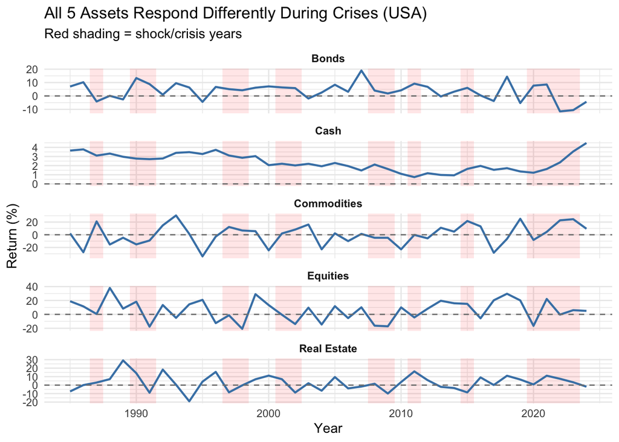

```r
asset_returns |>
  filter(country == "USA") |>
  pivot_longer(cols = c(equities, bonds, real_estate, commodities, cash),
               names_to = "asset",
               values_to = "return") |>
  mutate(asset = str_to_title(str_replace_all(asset, "_", " ")),
         shock = ifelse(is.na(shock_event), "No Shock", "Shock")) |>
  ggplot(aes(x = year, y = return)) +
  # shade every shock year
  annotate("rect", xmin = 1986.5, xmax = 1987.5, ymin = -Inf, ymax = Inf, alpha = 0.1, fill = "red") +
  annotate("rect", xmin = 1989.5, xmax = 1991.5, ymin = -Inf, ymax = Inf, alpha = 0.1, fill = "red") +
  annotate("rect", xmin = 1996.5, xmax = 1998.5, ymin = -Inf, ymax = Inf, alpha = 0.1, fill = "red") +
  annotate("rect", xmin = 2000.5, xmax = 2002.5, ymin = -Inf, ymax = Inf, alpha = 0.1, fill = "red") +
  annotate("rect", xmin = 2007.5, xmax = 2009.5, ymin = -Inf, ymax = Inf, alpha = 0.1, fill = "red") +
  annotate("rect", xmin = 2010.5, xmax = 2011.5, ymin = -Inf, ymax = Inf, alpha = 0.1, fill = "red") +
  annotate("rect", xmin = 2014.5, xmax = 2015.5, ymin = -Inf, ymax = Inf, alpha = 0.1, fill = "red") +
  annotate("rect", xmin = 2019.5, xmax = 2023.5, ymin = -Inf, ymax = Inf, alpha = 0.1, fill = "red") +
  geom_line(color = "steelblue", linewidth = 0.8) +
  geom_hline(yintercept = 0, linetype = "dashed", color = "gray50") +
  facet_wrap(~asset, ncol = 1, scales = "free_y") +
  labs(
    title = "All 5 Assets Respond Differently During Crises (USA)",
    subtitle = "Red shading = shock/crisis years",
    x = "Year", y = "Return (%)"
  ) +
  theme_minimal(base_size = 11) +
  theme(strip.text = element_text(face = "bold"))
```

### 2. Do macro signals mean the same thing in developed and emerging markets?

Macroeconomic variables such as inflation and policy rates may reflect fundamentally different economic conditions depending on a country’s level of development. We want to explore whether emerging markets exhibit wider ranges of inflation, interest rates, and currency movement than developed markets, indicating greater levels of macroeconomic volatility and instability. The goal is to demonstrate that the same signal, such as high inflation or elevated policy rates, can represent policy tightening in developed markets but crisis risk, inflation instability, or currency pressure in emerging markets.

The chart below compares inflation rates and policy rates across two developed markets (USA and Germany) and two emerging markets (Argentina and Brazil). Emerging markets exhibit substantially higher and more volatile inflation over time, often paired with dramatically higher policy rates. In contrast, developed markets remain within relatively stable inflation and interest-rate ranges, suggesting that the same macroeconomic signal may reflect very different underlying economic conditions depending on the country.

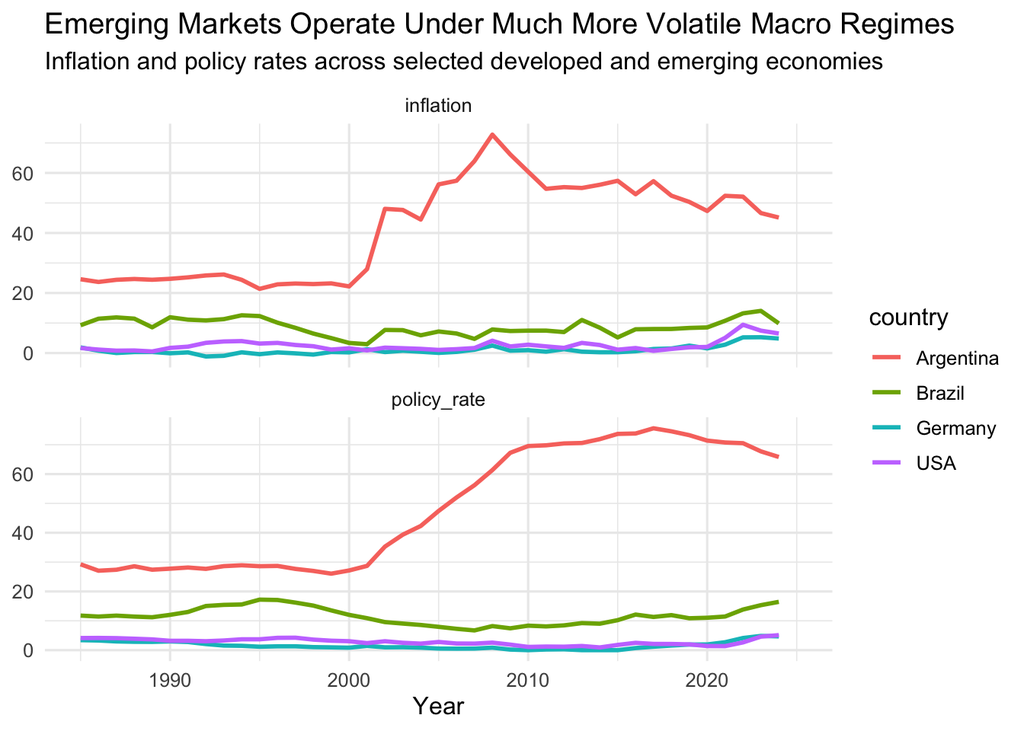

```r
selected <- c("USA", "Germany", "Argentina", "Brazil")

macro_long <- macro_indicators |>
  filter(country %in% selected) |>
  select(country, year, inflation, policy_rate) |>
  pivot_longer(
    cols = c(inflation, policy_rate),
    names_to = "variable",
    values_to = "value"
  )

macro_long |>
  ggplot(aes(x = year, y = value, color = country)) +
  geom_line(linewidth = 1) +
  facet_wrap(~variable, scales = "free_y", ncol = 1) +
  scale_x_continuous(limits = c(1985, 2025)) +
  labs(
    title = "Emerging Markets Operate Under Much More Volatile Macro Regimes",
    subtitle = "Inflation and policy rates across selected developed and emerging economies",
    x = "Year",
    y = NULL
  ) +
  theme_minimal(base_size = 12)
```

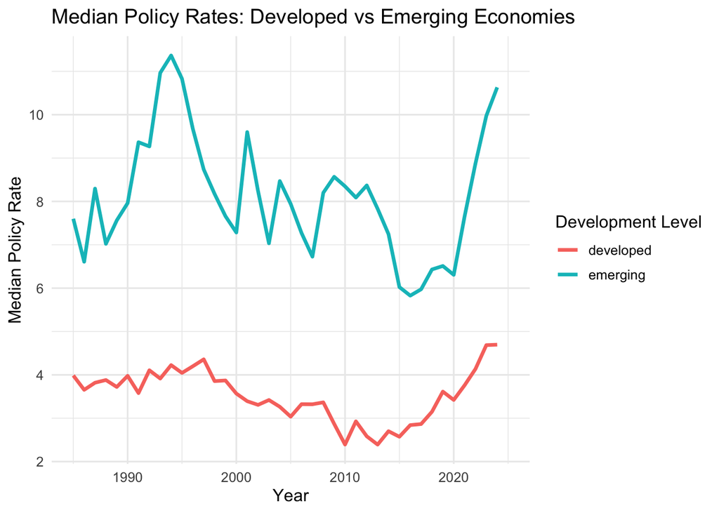

```r
macro_median <- macro_indicators |>
  filter(dev_level %in% c("developed", "emerging")) |>
  group_by(year, dev_level) |>
  summarize(
    median_policy_rate = median(policy_rate, na.rm = TRUE),
    .groups = "drop"
  )

macro_median |>
  ggplot(aes(x = year, y = median_policy_rate, color = dev_level)) +
  geom_line(linewidth = 1.2) +
  scale_x_continuous(limits = c(1985, 2025)) +
  labs(
    title = "Median Policy Rates: Developed vs Emerging Economies",
    x = "Year",
    y = "Median Policy Rate",
    color = "Development Level"
  ) +
  theme_minimal(base_size = 12)
```

### 3. Does inflation alone determine asset performance, or does policy response matter more?

Asset returns during inflationary periods may depend not only on the level of inflation itself, but also on how central banks respond through monetary policy. We want to explore whether traditional hedges such as bonds continue to provide protection during periods of rising inflation and increasing policy rates. The goal is to show that macroeconomic regimes are shaped by the interaction between inflation and policy response, rather than by a single variable in isolation.

We split developed-market country-years into inflation buckets and compare bond returns depending on whether policy rates were rising or remaining flat/falling. This approach better captures the role of monetary policy response rather than simply comparing high- and low-rate environments. The chart suggests that bonds behave differently across inflation regimes: during moderate inflation, bond returns remain relatively stable regardless of policy direction, but during higher inflation periods, bond performance weakens significantly when central banks continue raising rates. This supports the idea that asset performance during inflation depends not only on inflation itself, but also on how policymakers respond to it.

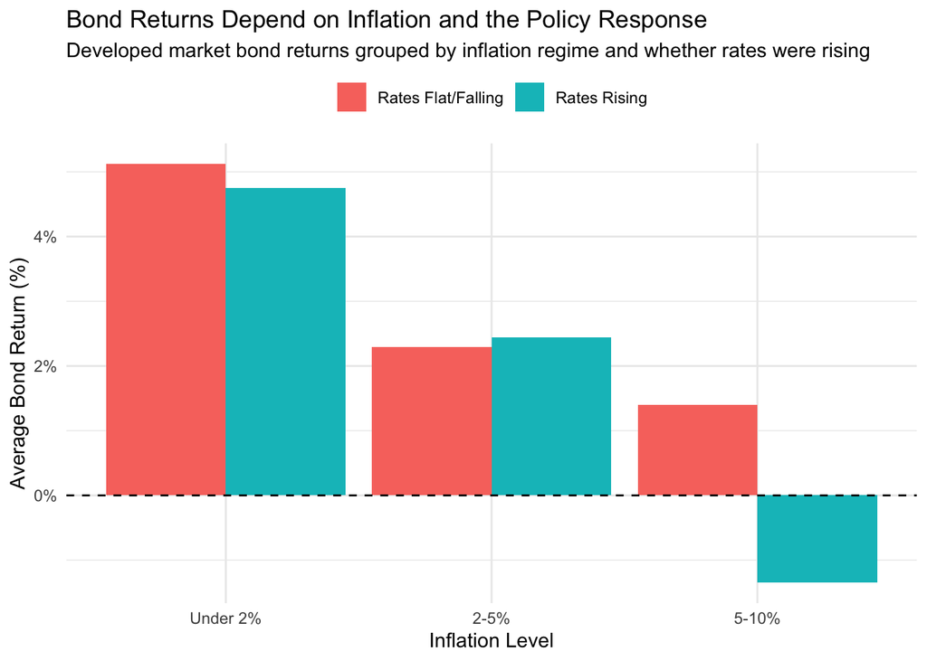

```r
joined <- asset_returns |>
  inner_join(
    macro_indicators,
    by = c("country", "year", "dev_level", "region", "shock_event")
  ) |>
  arrange(country, year) |>
  group_by(country) |>
  mutate(
    policy_change = policy_rate - lag(policy_rate),
    policy_response = case_when(
      policy_change > 0 ~ "Rates Rising",
      policy_change <= 0 ~ "Rates Flat/Falling",
      TRUE ~ NA_character_
    ),
    inflation_bucket = cut(
      inflation,
      breaks = c(-Inf, 2, 5, 10, Inf),
      labels = c("Under 2%", "2-5%", "5-10%", "Over 10%")
    )
  ) |>
  ungroup()

joined |>
  filter(dev_level == "developed", !is.na(policy_response)) |>
  group_by(inflation_bucket, policy_response) |>
  summarize(
    avg_bond = mean(bonds, na.rm = TRUE),
    n = n(),
    .groups = "drop"
  ) |>
  ggplot(aes(x = inflation_bucket, y = avg_bond, fill = policy_response)) +
  geom_col(position = "dodge") +
  geom_hline(yintercept = 0, linetype = "dashed", color = "black") +
  scale_y_continuous(labels = scales::percent_format(scale = 1, suffix = "%")) +
  labs(
    title = "Bond Returns Depend on Inflation and the Policy Response",
    subtitle = "Developed market bond returns grouped by inflation regime and whether rates were rising",
    x = "Inflation Level",
    y = "Average Bond Return (%)",
    fill = NULL
  ) +
  theme_minimal() +
  theme(legend.position = "top")
```

## Conclusion + Next Steps

Going forward, we plan to refine these communication goals into a connected interactive narrative. We want to further explore how different crises reshape asset “winners” and “losers,” investigate how macroeconomic signals differ across developed and emerging markets, and analyze how inflation and monetary policy interact to influence asset returns. In future milestones, we plan to experiment with more polished and interactive visualizations, including heatmaps, regime matrices, and interactive scatterplots, that allow users to explore these macro relationships across countries, time periods, and asset classes.